# Modélisation de la probabilité de résignation

22/04/2020

## Plan de la présentation

- Importance de la prédiction de résignation
- Exploration des données utilisées
- Prétraitement des données et exploration non-supevisée
- Description des modèles considérés
- Performance et interprétation des meilleurs modèles
- Conclusion

## Importance de la prédiction de résignation

- Élasticité: \[ \text{Élasticité} = \frac{\Delta Pr[\text{Renouvellement}]}{\Delta \text{Augmentation prix}} \]

## Descriptions du jeu de données

- 23060 observations
- 8 variables numériques
- 8 variables catégoriels
- 2 variables ordonnées
- 1 Variable crée: \[ \text{prem_index} = \frac{\text{prem_final}}{\text{prem_last}} \]
- 1 Variable réponse:
  - 87 % Renouvellement
  - 13 % Résignation

## Analyse exploratoire des données

## Variables concernant la prime

### Augmentation au renouvellement

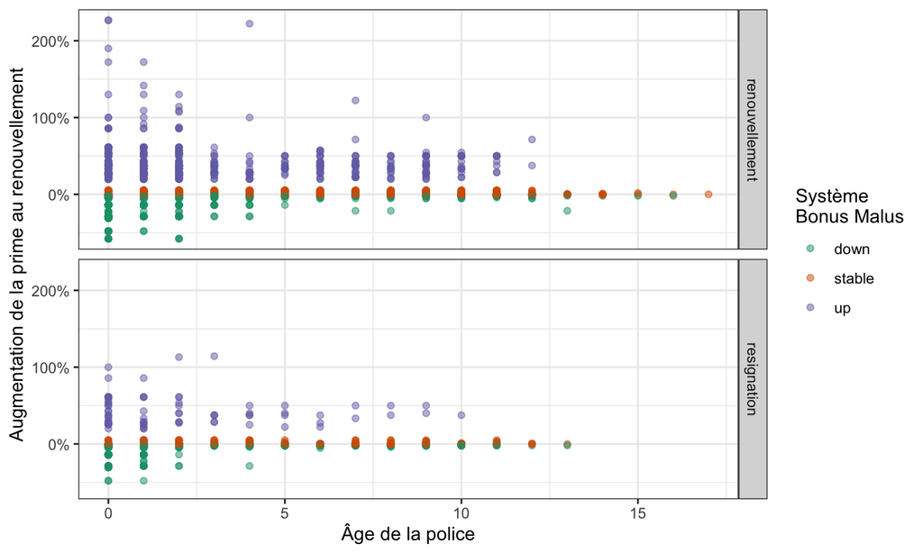

## Variables concernant la prime

### Écart entre la prime chargée et la prime pure

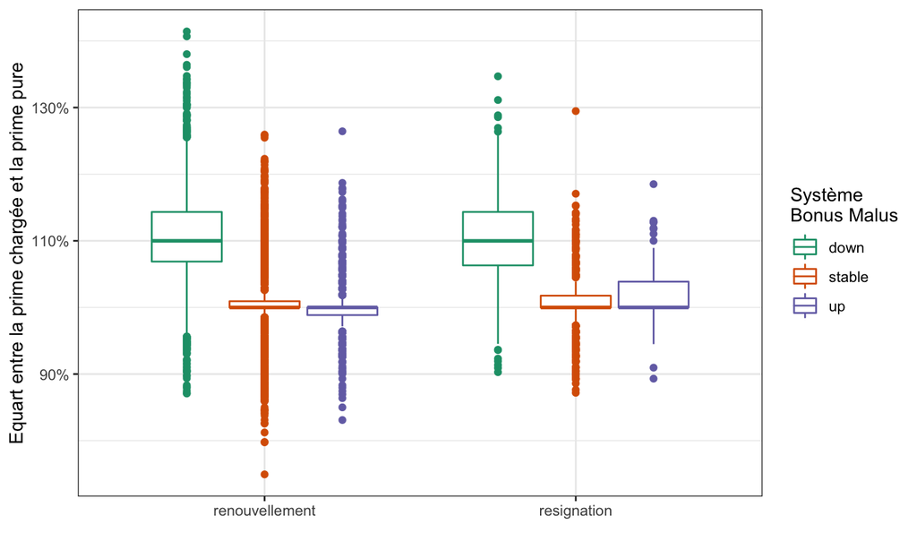

## Police commerciale

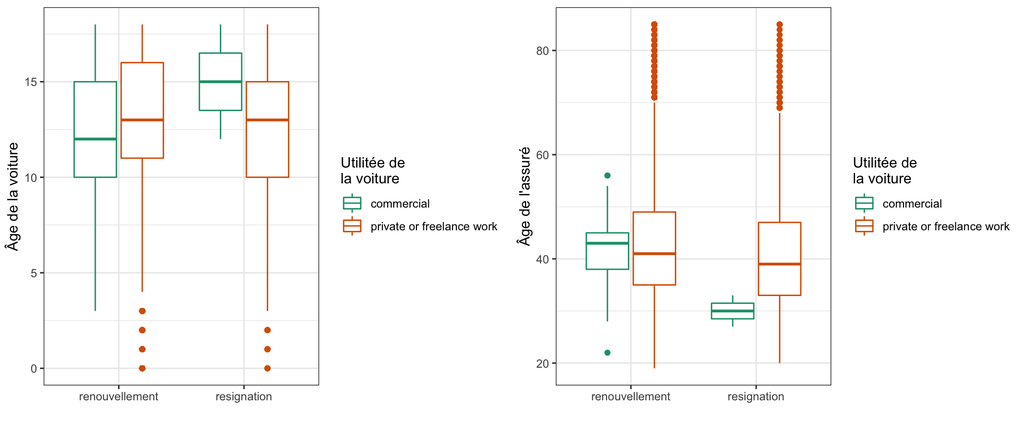

## Region géographique

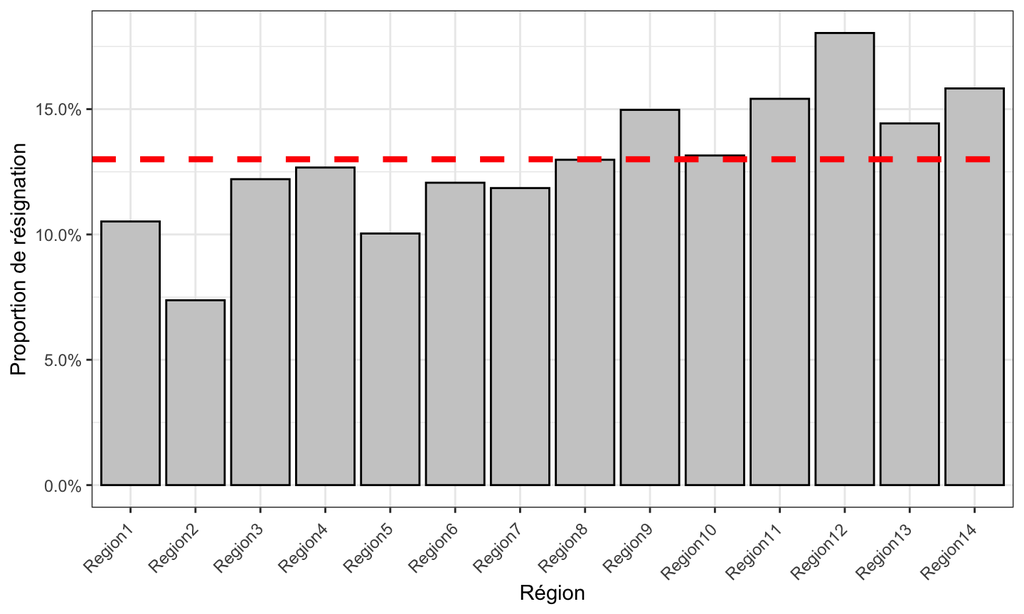

## Prétraitement des données

### Traitement des valeurs manquantes

- policy_caruse: 3483
- vehicl_garage: 1575
- polholder_diffdriver: 12
- Nombre d'observations touchées: 4546 (19.71%)
- Les données ne sont pas MCAR
- Imputation multiple

## Prétraitement des données

### Modification de vehicl_powerkw

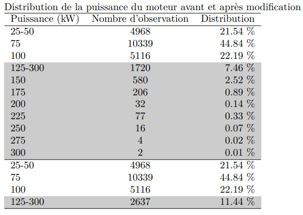

## Description des modèles

## Modèle de base

- GLM Bernoulli
- Modélisation de la probabilité de résignation avec régression logistique

\[\ln \frac{\pi_{res}}{1 - \pi_{res}} = \beta_0 + \sum_{i=1}^p \beta_i x_i\] - Estimateurs \(\beta_{i}\) \[ \max\limits_{(\beta_0, \beta_j)} exp\left\{ \sum_{i=1}^n \left( y_{i} (\beta_{0} + \sum_{j=1}^p \beta_{j} x_{j} ) - ln \left(1 + e^{\beta_{0} + \sum\limits_{j=1}^p \beta_{j} x_{j}} \right)\right) \right\}\] - TRV 1% pour la sélection de variable

## Modèle linéaire avec régularisation

- GLM Bernoulli avec régularisation Lasso
- Modélisation de la probabilité de résignation avec régression logistique
- Estimateurs \(\beta_{i}\)
- Optimisation de l'hyperparamètre \(\lambda\)

## Modèle linéaire avec régularisation

### Optimisation de l'hyperparamètre \(\lambda\)

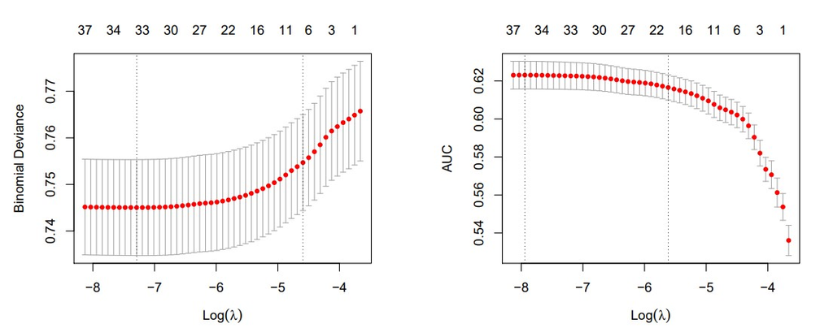

## Modèle linéaire avec régularisation

### Variables avec coeffcient nul de la régulation Lasso

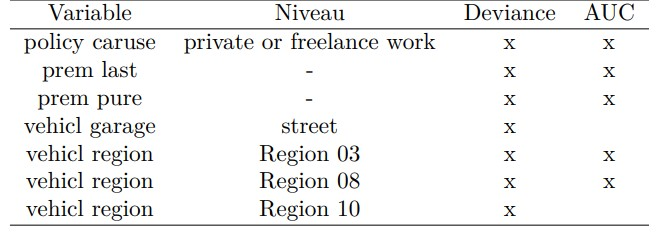

## Modèles k plus proches voisins

- Utilisation de la distance euclédienne
- Transformation des variables catégorielles non-ordonnées en variables binaires
- Transformation des variables ordonnées en numérique discrète (1, 2, …)
- Prédiction de la probabilité de résignation par régression

## Modèles k plus proches voisins

### Optimisation de l'hyperparamètre k

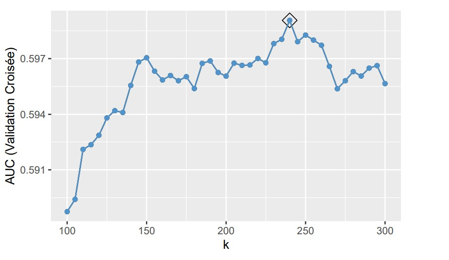

## Arbre de classification

- Processus de partitionnement récursif binaire
- Deux fonctions de perte testée \[ \mathcal{L}_G = \sum_{k=1}^K \widehat{P}_{mk} (1 - \widehat{P}_{mk}) \qquad \mathcal{L}_D = - \sum_{k=1}^K \widehat{P}_{mk} \ln( \widehat{P}_{mk}) \]
- Complexité de l'arbre sera optimisée en fonction de deux paramètres

## Arbre de classification

### Optimisation des hyperparamètres

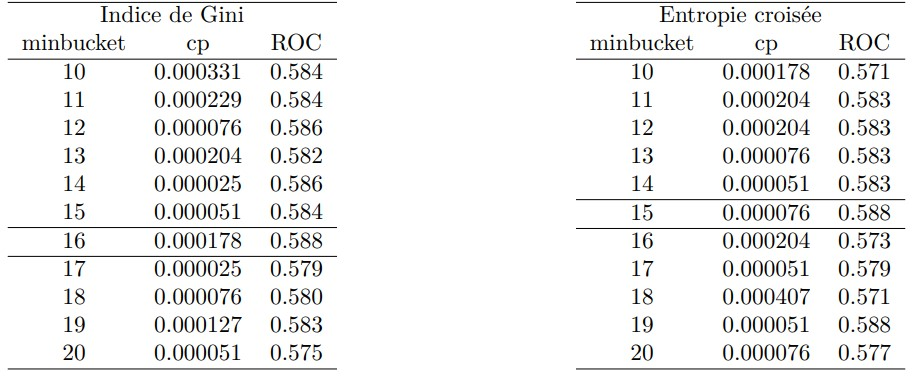

## Bagging

- Prévision obtenue par l'aggrégation d'arbres de classification
- Chaque arbre utilise l'indice de Gini
- Nombre d'arbre nécessaire

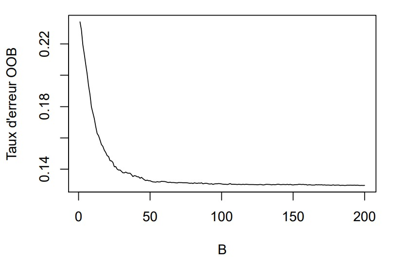

## Forêt aléatoire

- Taille de l'échantillon boostrap de 50%
- Nombre d'arbre nécessaire

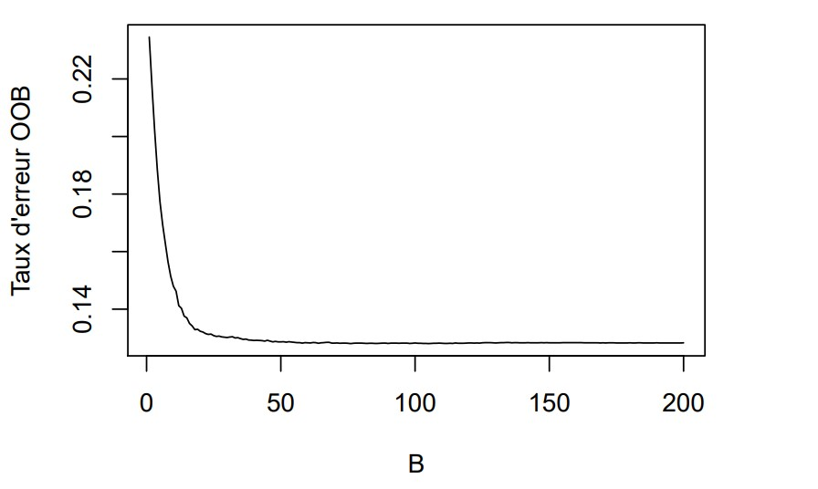

- Deux hyperparamètre à optimiser

## Forêt aléatoire

### Optimisation des hyperparamètres

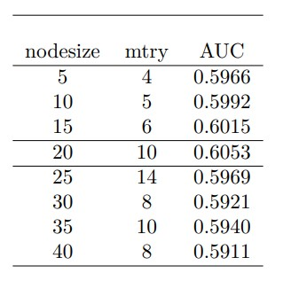

## Boosting de gradient stochastique

Amélioration à l'itération t \[ \sum_{i=1}^n \mathcal{L} \left\{ y_i, \widehat{f}_{t-1}(x_i) + \widehat{f}_{\text{arbre}}^t(x_i) \right\} \]

Avec fonction de perte \[ \mathcal{L} = \sum_{k=1}^2 \widehat{P}_{ik} \ln( \widehat{P}_{ik}) \]

Taux d'apprentissage \(\lambda = 0.005\) , sous-échantillonnage de 75%

Deux hyperparamètre à optimiser

[output not shown]

## Boosting de gradient stochastique

### Optimisation des hyperparamètres

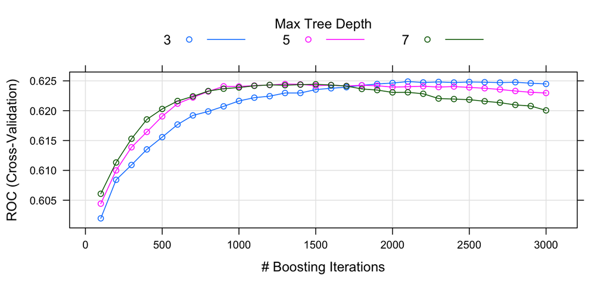

```
##    n.trees interaction.depth
## 21    2100                 3
```

## Interprétation des meilleurs modèles

## Modèle de base

- Modélisation avec lien logistique

\[\ln \frac{\pi_{res}}{1 - \pi_{res}} = \beta_0 + \sum_{i=1}^p \beta_i x_i\]

- Impact des coefficients sur la prévision

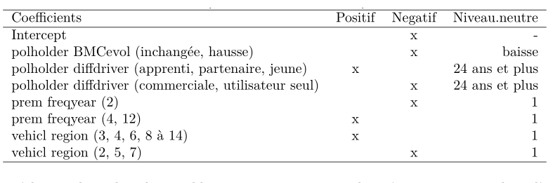

## Modèle de boosting de gradient stochastique

### Importance des variables

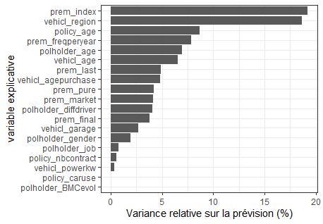

## Modèle de boosting de gradient stochastique

### Graphique de dépendance partielle sur prem_index

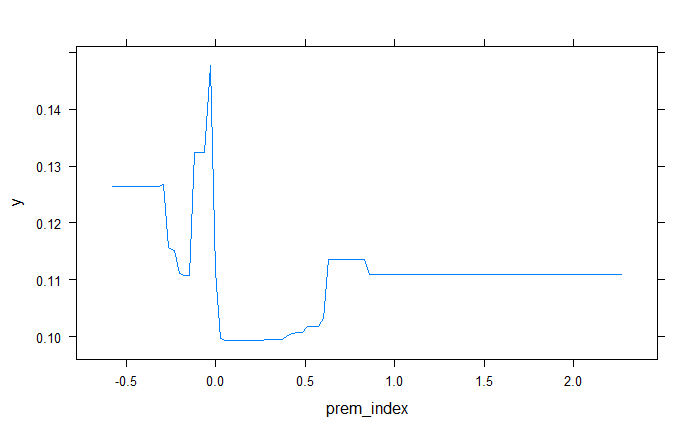

## Modèle de boosting de gradient stochastique

### Graphique de dépendance partielle sur vehicl_region

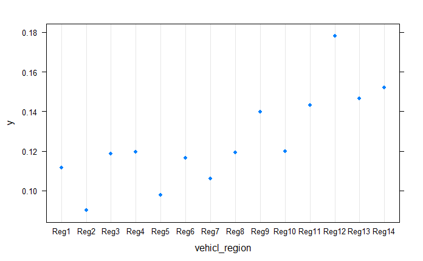

## Modèle de boosting de gradient stochastique

### Graphique de dépendance partielle sur policy_age

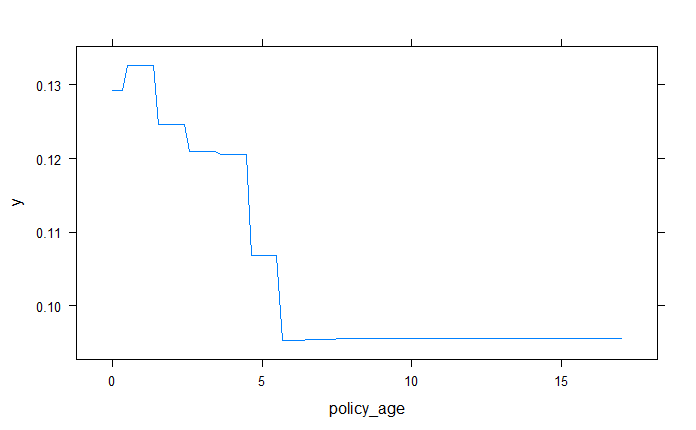

## Modèle de boosting de gradient stochastique

### Graphique de dépendance partielle sur prem_freqperyear

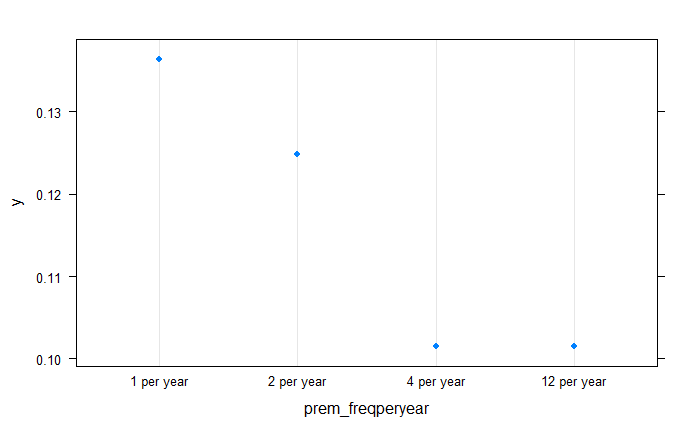

## Modèle de boosting de gradient stochastique

### Statistique H de Friedman

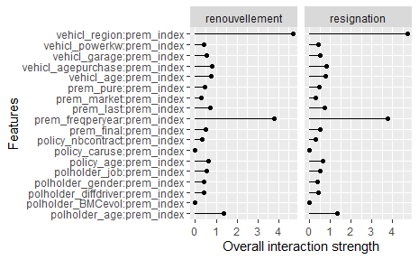

## Modèle de boosting de gradient stochastique

### Interaction entre prem_index et vehicl_region (DPD bivarié)

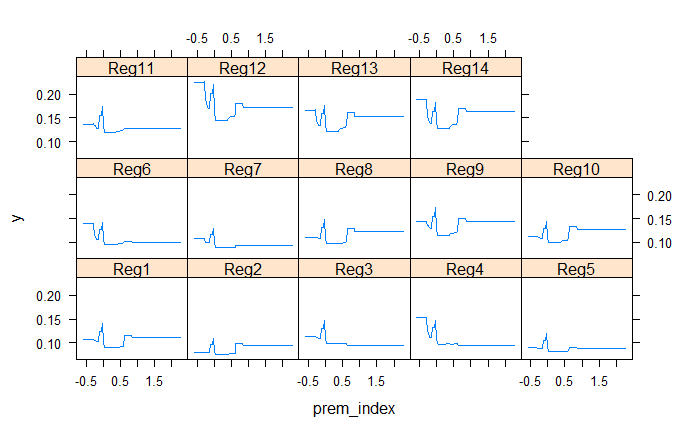

## Performance des meilleurs modèles

## Tableaux de confusion

Modèle de base :

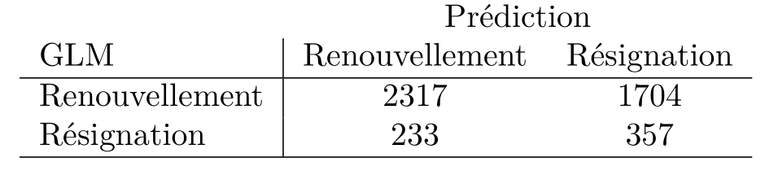

Modèle de boosting de gradient stochastique

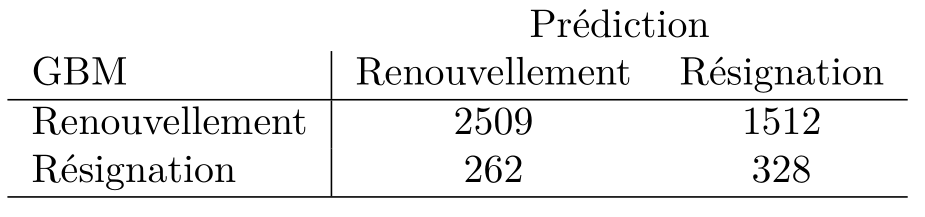

[figure not shown]

## Conclusion

[figure not shown]

## Prétraitement des données

### Traitement des valeurs manquantes

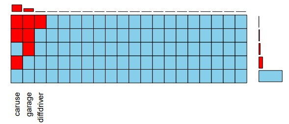

- Nombre d’observations touchées: 4546 (19.71%)
- Les données ne sont pas MCAR
- Imputation multiple

## Prétraitement des données

### Modification de vehicl_powerkw

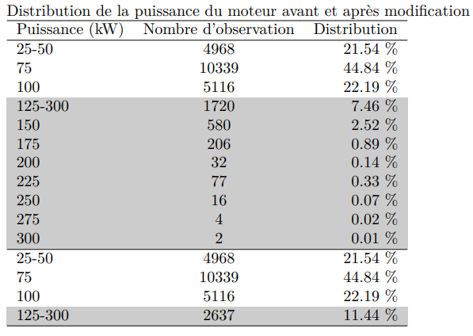

## Description des modèles

## Modèle de base

- GLM Bernoulli
- Modélisation de la probabilité de résignation avec régression logistique

\[\ln \frac{\pi_{res}}{1 - \pi_{res}} = \beta_0 + \sum_{i=1}^p \beta_i x_i\] - Estimateurs \(\beta_{i}\) \[ \mathcal{L}(\beta_{0}, \ldots, \beta_{p}) = \max\limits_{(\beta_0, \beta_j)} exp\left\{ \sum_{i=1}^n \left( y_{i} (\beta_{0} + \sum_{j=1}^p \beta_{j} x_{j} ) - ln \left(1 + e^{\beta_{0} + \sum\limits_{j=1}^p \beta_{j} x_{j}} \right)\right) \right\}\] - TRV 99% pour la sélection de variable

## Modèle linéaire avec régularisation

- GLM Bernoulli avec régularisation Lasso
- Modélisation de la probabilité de résignation avec régression logistique
- Estimateurs \(\beta_{i}\)

\[\max _{\left(\beta_{0}, \beta_{j}\right)} \mathcal{L}(\beta_{0}, \ldots, \beta_{p}) - \lambda \sum_{j=1}^{p}\left|\beta_{j}\right|\]

- Optimisation de l’hyperparamètre \(\lambda\)

## Modèle linéaire avec régularisation

### Optimisation de l’hyperparamètre \(\lambda\)

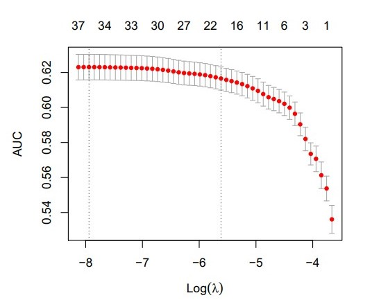

## Modèle linéaire avec régularisation

### Variables avec coeffcient nul

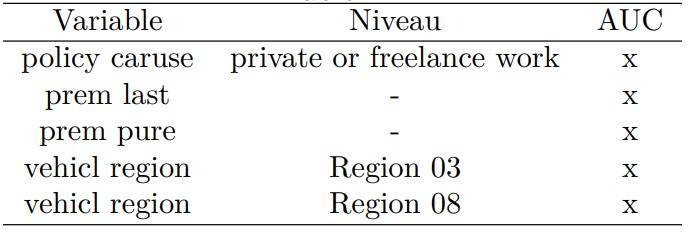

## Modèles k plus proches voisins

- Utilisation de la distance euclédienne
- Transformation des variables catégorielles non-ordonnées en variables binaires
- Transformation des variables ordonnées en numérique discrète (1, 2, …)
- Prédiction de la probabilité de résignation par régression

## Modèles k plus proches voisins

### Résultats de l’optimisation

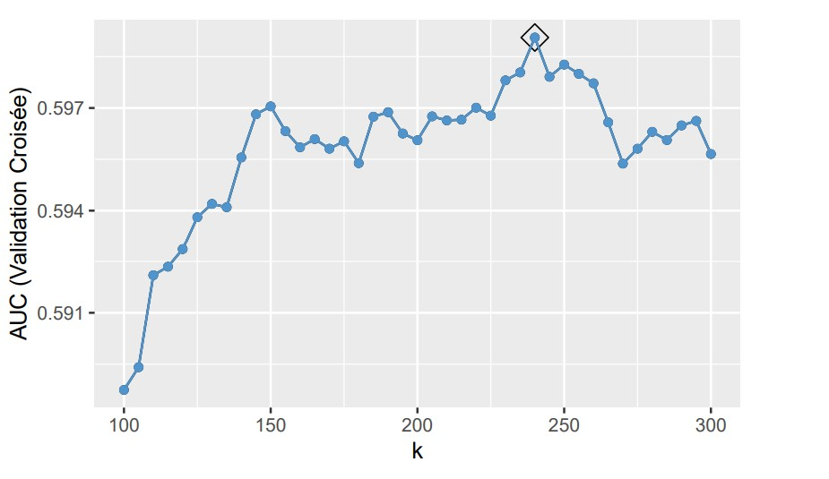

## Arbre de classification

- Processus de partitionnement récursif binaire
- Deux fonctions de perte testée \[ \mathcal{L}_G = \sum_{k=1}^K \widehat{P}_{mk} (1 - \widehat{P}_{mk}) \qquad \mathcal{L}_D = - \sum_{k=1}^K \widehat{P}_{mk} \ln( \widehat{P}_{mk}) \]
- Complexité de l’arbre sera optimisée en fonction de deux paramètres
  - paramètre de complexité (cp)
  - nombre minimal d’observations dans une feuille (minbucket)

## Bagging

- Prévision obtenue par l’aggrégation d’arbres de classification
- Chaque arbre utilise l’indice de Gini
- Nombre d’arbre nécessaire

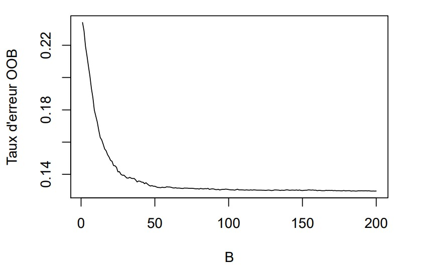

- Paramètre optimisé: taille minimale d’un noeud (nodesize)